### Predict the manner in which subject did the exercise

### Background

Using devices such as Jawbone Up, Nike FuelBand, and Fitbit it is now possible to collect a large amount of data about personal activity relatively inexpensively. These type of devices are part of the quantified self movement - a group of enthusiasts who take measurements about themselves regularly to improve their health, to find patterns in their behavior, or because they are tech geeks. One thing that people regularly do is quantify how much of a particular activity they do, but they rarely quantify how well they do it. In this project, your goal will be to use data from accelerometers on the belt, forearm, arm, and dumbell of 6 participants. They were asked to perform barbell lifts correctly and incorrectly in 5 different ways. More information is available from the website here: http://groupware.les.inf.puc-rio.br/har (see the section on the Weight Lifting Exercise Dataset).

#### Data collection:

##### Data

The training data for this project are available here:

https://d396qusza40orc.cloudfront.net/predmachlearn/pml-training.csv

The test data are available here:

https://d396qusza40orc.cloudfront.net/predmachlearn/pml-testing.csv

The function createDataPartition used to create a stratified random splits of the data set. In this case 70% of the data will be used for model training and remainder will be used for evaluating model performance and also to report the out of sample error. This data was not used in the process of traing the model, so the reported out of sample error using this data can be considered as near to accurate.

The function creates the random splits within each class so that the overall class distribution is preserved as well as possible.

```r
# Data partition into traing and cross vaidation
inTrain = createDataPartition(pmlTraining$classe, p = .7, list=FALSE)
pmlTrain = pmlTraining[ inTrain,]
pmlTest = pmlTraining[-inTrain,]

dim(pmlTrain)
```

```
## [1] 13737   160
```

### Preprocessing

```r
# Dummy variables, remove near zero variance variables
nsv<-nearZeroVar(pmlTrain)
trainData<-pmlTrain[,-nsv]

# discard columns with most NAs
NAs <- apply(trainData,2,function(x) {sum(is.na(x))})
trainData <- trainData[,which(NAs == 0)]

# discards unuseful predictors
removeIndex <- grep("timestamp|X|user_name|new_window|num_window",names(trainData))
trainData <- trainData[,-removeIndex]
```

#### Building and Model Selection

##### Basic Parameter Tuning

By default, simple bootstrap resampling is used the algorithm above. The function trainControl used to specifiy the algorithm to use cross validation to select the final model.

```r
fitControl<-trainControl(method = "cv", number = 4,allowParallel=TRUE )
```

##### Model creation

Choose to build and compare Recursive Partitioning and Radom Forests models.

```r
rpartmodelFit<- train(trainData$classe ~ ., data=trainData, method="rpart", trControl=fitControl)
rfmodelFit <- train(trainData$classe ~ ., data=trainData, method="rf", trControl=fitControl)
```

##### Model Selection

Used different methods to compare the two models.

```r
confusionMatrix(pmlTest$classe, predict(rpartmodelFit, pmlTest))
```

```
## Confusion Matrix and Statistics
##
##           Reference
## Prediction    A    B    C    D    E
##          A 1505   24  142    0    3
##          B  472  373  294    0    0
##          C  487   33  506    0    0
##          D  422  177  365    0    0
##          E  158  165  277    0  482
##
## Overall Statistics
##
##                Accuracy : 0.487
##                  95% CI : (0.474, 0.5)
##     No Information Rate : 0.517
##     P-Value [Acc > NIR] : 1
##
##                   Kappa : 0.33
##  Mcnemar's Test P-Value : NA
##
## Statistics by Class:
##
##                      Class: A Class: B Class: C Class: D Class: E
## Sensitivity             0.494   0.4832    0.319       NA   0.9938
## Specificity             0.941   0.8502    0.879    0.836   0.8889
## Pos Pred Value          0.899   0.3275    0.493       NA   0.4455
## Neg Pred Value          0.635   0.9159    0.778       NA   0.9994
## Prevalence              0.517   0.1312    0.269    0.000   0.0824
## Detection Rate          0.256   0.0634    0.086    0.000   0.0819
## Detection Prevalence    0.284   0.1935    0.174    0.164   0.1839
## Balanced Accuracy       0.717   0.6667    0.599       NA   0.9414
```

```r
confusionMatrix(pmlTest$classe, predict(rfmodelFit, pmlTest))
```

```
## Confusion Matrix and Statistics
##
##           Reference
## Prediction    A    B    C    D    E
##          A 1673    1    0    0    0
##          B    2 1136    1    0    0
##          C    0    8 1018    0    0
##          D    0    0   11  952    1
##          E    0    0    0    0 1082
##
## Overall Statistics
##
##                Accuracy : 0.996
##                  95% CI : (0.994, 0.997)
##     No Information Rate : 0.285
##     P-Value [Acc > NIR] : <2e-16
##
##                   Kappa : 0.995
##  Mcnemar's Test P-Value : NA
##
## Statistics by Class:
##
##                      Class: A Class: B Class: C Class: D Class: E
## Sensitivity             0.999    0.992    0.988    1.000    0.999
## Specificity             1.000    0.999    0.998    0.998    1.000
## Pos Pred Value          0.999    0.997    0.992    0.988    1.000
## Neg Pred Value          1.000    0.998    0.998    1.000    1.000
## Prevalence              0.285    0.195    0.175    0.162    0.184
## Detection Rate          0.284    0.193    0.173    0.162    0.184
## Detection Prevalence    0.284    0.194    0.174    0.164    0.184
## Balanced Accuracy       0.999    0.996    0.993    0.999    1.000
```

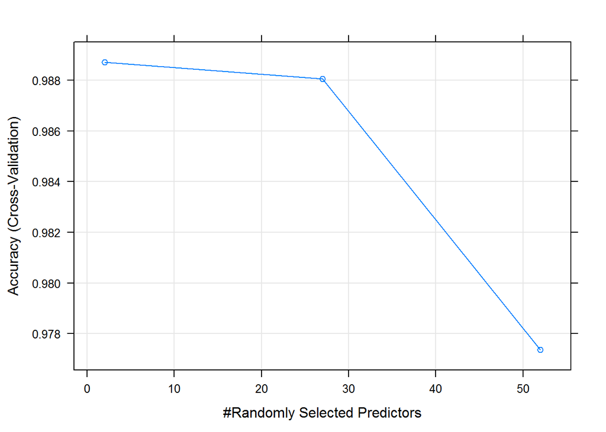

```r
plot(rfmodelFit)
```

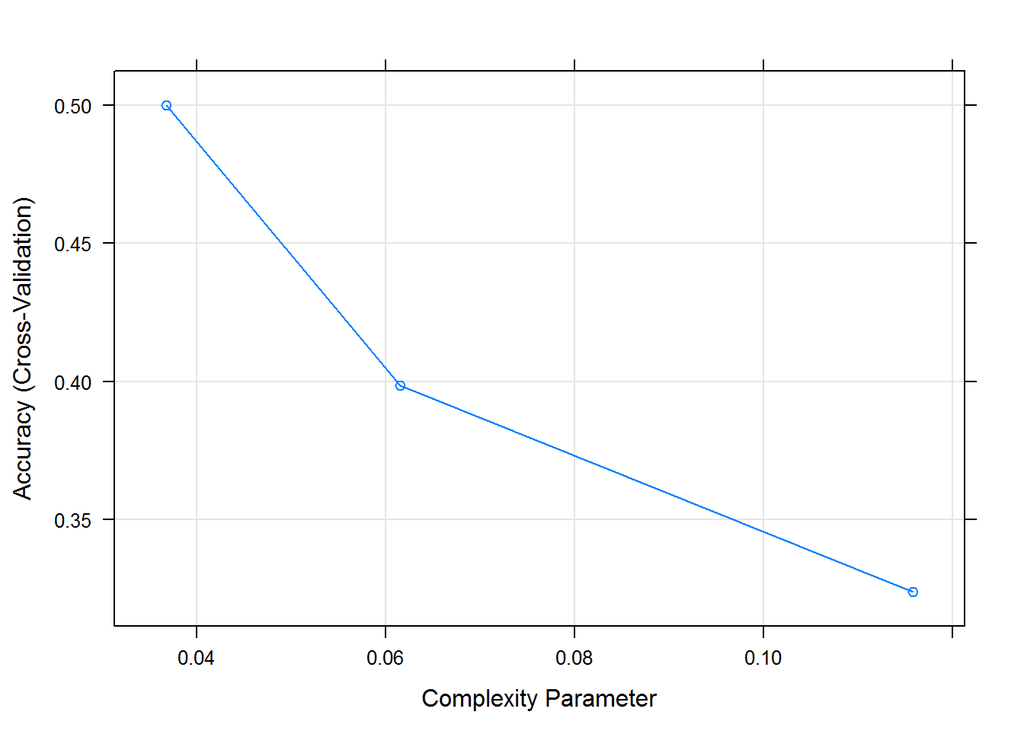

```r
plot(rpartmodelFit)
```

```r
resamps <- resamples(list(RPART = rpartmodelFit,
                          rf = rfmodelFit
                          ))
summary(resamps)
```

```
##
## Call:
## summary.resamples(object = resamps)
##
## Models: RPART, rf
## Number of resamples: 4
##
## Accuracy
##        Min. 1st Qu. Median  Mean 3rd Qu.  Max. NA's
## RPART 0.492   0.499  0.501 0.500   0.503 0.506    0
## rf    0.985   0.987  0.988 0.989   0.990 0.994    0
##
## Kappa
##        Min. 1st Qu. Median  Mean 3rd Qu.  Max. NA's
## RPART 0.336   0.344  0.348 0.346   0.350 0.353    0
## rf    0.980   0.984  0.985 0.986   0.987 0.992    0
```

Random Forest achieved 99% percent accuracy on the test data, which will be selected and used to predict the 20 different test cases.

```r
## Calculate the out of sample error
ooer<- 1 - ( sum( predict(rfmodelFit, pmlTest) == pmlTest$classe) / nrow(pmlTest) )
```

**Expected out of sample error is 0.0041.**

### Prediction of Test samples

Rsulats of Prediction of 20 provided test cases.

```r
answers = rep("A", 20)
answers<-predict(rfmodelFit, pmlTesting)
answers
```

```
##  [1] B A B A A E D B A A B C B A E E A B B B
## Levels: A B C D E
```

##### Citation

The data for this project come from this source: http://groupware.les.inf.puc-rio.br/har. If you use the document you create for this class for any purpose please cite them as they have been very generous in allowing their data to be used for this kind of assignment.